# Caloric Suitability Indices (CSI)

[Galor and Özak (2014)](https://ideas.repec.org/p/smu/ecowpa/1407.html) introduce novel measures of potential crop yield measured in calories for the pre-industrial and modern eras. In particular, for each cell of size $5'\times5'$ in the world, they estimate the maximum caloric yield and the growth cycle attainable given the set of crops available before and after the Columbian Exchange. Using the same methodology, additional Caloric Suitability Indices (CSI) are introduced here based on the average and total caloric yields attainable given the crops available before and after the Columbian Exchange.

These historical measures are constructed based on data from the [Global Agro-Ecological Zones (GAEZ)](http://http://gaez.fao.org/) project of the Food and Agriculture Organization (FAO). The GAEZ project supplies global estimates of crop yield and crop growth cycle for 48 crops in grids with cells size of $5'\times5'$ (i.e., approximately 100 km$^2$).

The crops available are alfalfa, banana, barley, buckwheat, cabbage, cacao, carrot, cassava, chickpea, citrus, coconut, coffee, cotton, cowpea, dry pea, flax, foxtail millet, greengram, groundnuts, indigo rice, maize, oat, oilpalm, olive, onion, palm heart, pearl millet, phaseolus bean, pigeon pea, rye, sorghum, soybean, sunflower, sweet potato, tea, tomato, wetland rice, wheat, spring wheat, winter wheat, white potato, yams, giant yams, subtropical sorghum, tropical highland sorghum, tropical lowland, sorghum, white yams.

For each crop, GAEZ provides estimates for crop yield based on three alternative levels of inputs -- high, medium, and low - and two possible categories of sources of water supply -- rain-fed and irrigation. Additionally, for each input-water source category, it provides two separate estimates for crop yield, based on agro-climatic conditions, that are arguably unaffected by human intervention, and agro-ecological constraints, that could potentially reflect human intervention.

In order to capture the conditions that were prevalent during the pre-industrial era, while mitigating potential endogeneity concerns, the indices use the estimates of potential crop yield under low level of inputs and rain-fed agriculture -- cultivation methods that characterized early stages of development. Moreover, the estimates of potential crop yield are based on agro-climatic constraints that are largely orthogonal to human intervention. Thus, these restrictions remove the potential concern that the level of agricultural inputs, the irrigation method, and soil quality, reflect endogenous choices that could be potentially correlated with individual preferences or institutional settings. Additionally, the choice of rain-fed conditions is further justified by the fact that, although some societies had access to irrigation prior to the industrial revolution, GAEZ's data only provides estimates based on irrigation infrastructure available during the late twentieth century

The FAO dataset provides for each cell in the agro-climatic grid the potential yield for each crop (measured in tons, per hectare, per year). These estimates account for the effect of temperature and moisture on the growth of the crop, the impact of pests, diseases and weeds on the yield, as well as climatic related "workability constraints".

In order to better capture the nutritional differences across crops, and thus to ensure comparability in the measure of crop yield, the yield of each crop in the GAEZ data (measured in tons, per hectare, per year) is converted into caloric return (measured in millions of kilo calories, per hectare, per year). This conversion is based on the caloric content of crops, as provided by the [United States Department of Agriculture Nutrient Database for Standard Reference](http://www.ars.usda.gov/Services/docs.htm?docid=23635). Using the estimates of the caloric content for each crop in the GAEZ data (measured in kilo calories per 1g), a comparable measure of crop yield (in millions of kilo calories, per hectare, per year) is constructed for each crop.

Based on these estimates [Galor and Özak (2014)](https://ideas.repec.org/p/smu/ecowpa/1407.html) construct the maximum potential caloric yield estimate they use in their paper. Here varios additional indices of caloric suitability are constructed and presented. First, for each cell the average caloric yield across all available crops pre- and post-1500CE is computed. Second, for each cell the total caloric yield across all available crops pre- and post-1500CE is computed. Finally, the analysis assigns to each cell the highest potential yield among the available crops pre- and post-1500CE. Additionally, for each caloric index raster the same index is constructed including and excluding cells where no calories can be produced or for averages the crops without caloric output are excluded.

Thus, the research constructs for each type of index, namely *Average*, *Total* and *Maximal* Caloric Suitability, four sets of grids:

```
1. Caloric Suitability pre-1500CE (without zeros)
2. Caloric Suitability pre-1500CE (with zeros)
3. Caloric Suitability post-1500CE (without zeros)
4. Caloric Suitability post-1500CE (with zeros)
```

These grids can be used to assess the exogenous effect of agricultural potential on various economic and social outcomes. The next section shows how it can be done and compares with another measure of agricultural suitability.

# Download Options for Caloric Suitability Indices

The **Caloric Suitability Indices** can be downloaded as a zip file, or individually. They come in GeoTiff format and WGS84 projection. Use the links below to download (or you can fork the associated Github repository which contains also this notebook).

- [All files (zip)](https://drive.google.com/uc?export=download&id=0By-h7HPv1NhVM1g5aW81TzVRWjQ)
- Pre-1500CE:
  - [Average Calories](https://drive.google.com/uc?export=download&id=0By-h7HPv1NhVeEhsRmdRWkFJX2M)
  - [Average Calories (No Zeros)](https://drive.google.com/uc?export=download&id=0By-h7HPv1NhVcHgxa1EyOEpURUk)
  - [Total Calories](https://drive.google.com/uc?export=download&id=0By-h7HPv1NhVMDNwWkZIMTltb3c)
  - [Total Calories (No Zeros)](https://drive.google.com/uc?export=download&id=0By-h7HPv1NhVb29EZ3Jvem1Ed1k)
  - [Maximum Calories](https://drive.google.com/uc?export=download&id=0By-h7HPv1NhVR2dDUm5fU2lMN2c)
  - [Maximum Calories (No Zeros)](https://drive.google.com/uc?export=download&id=0By-h7HPv1NhVUzVDTXBST3d4YlE)
- Post-1500CE:
  - [Average Calories](https://drive.google.com/uc?export=download&id=0By-h7HPv1NhVT05GNGtaZk13S2M)
  - [Average Calories (No Zeros)](https://drive.google.com/uc?export=download&id=0By-h7HPv1NhVcHVJcmgtb09FTXM)
  - [Total Calories](https://drive.google.com/uc?export=download&id=0By-h7HPv1NhVRmZ2bmZTbS1lajg)
  - [Total Calories (No Zeros)](https://drive.google.com/uc?export=download&id=0By-h7HPv1NhVb3ZxZmZrb0ZpTXc)
  - [Maximum Calories](https://drive.google.com/uc?export=download&id=0By-h7HPv1NhVR2ZDemhYd1hqZms)
  - [Maximum Calories (No Zeros)](https://drive.google.com/uc?export=download&id=0By-h7HPv1NhVajhjbVcyakFYMHc)

# Caloric Crop Suitability and Agricultural Suitability

This section plots the various Caloric Suitability Indices constructed following [Galor and Özak (2014)](https://ideas.repec.org/p/smu/ecowpa/1407.html) and introduced in the previous section. Additionally, it compares them to the agricultural suitability index of [Rammankutty, Foley, Norman, and McSweeney (2001)](http://www.sage.wisc.edu/atlas/maps.php?datasetid=19&includerelatedlinks=1&dataset=19)

Additionally, it shows how one can use open source tools, in particular Python, to extract data. In order to do the analysis a working installation of Scientific Python is required and the packages imported below have to be installed also. If needed, follow the installation instructions [here](http://ozak.github.io/CompEcon/) or view [this notebook](http://nbviewer.ipython.org/github/ozak/CompEcon/blob/master/notebooks/IntroPython.ipynb).

Start by importing the modules to be used.

```python
from __future__ import division
import sys, os, time
# Math, data
import numpy as np
import pandas as pd
pd.set_option('display.width', 140)
# GIS packages
from rasterstats import zonal_stats
import geopandas as gp
import georasters as gr
from shapely.geometry import Polygon
from fiona.crs import from_string
import mplleaflet
import folium
```

```python
%matplotlib inline
folium.initialize_notebook()
from IPython.display import display
from IPython.display import DisplayObject
```

## Import Post-1500CE Caloric Suitability Indices

```python
post1500mean = gr.from_file('../data/post1500AverageCalories.tif')
post1500tot = gr.from_file('../data/post1500TotalCalories.tif')
post1500mean0 = gr.from_file('../data/post1500AverageCaloriesNo0.tif')
post1500tot0 = gr.from_file('../data/post1500TotalCaloriesNo0.tif')
post1500max = gr.from_file('../data/post1500OptCalories.tif')
post1500max0 = gr.from_file('../data/post1500OptCaloriesNo0.tif')
```

### Names ending with zero (0) exclude zeros in their construction

In particular, this means, that if for a cell $c$, $n$ of the 48 crops in the FAO GAEZ data are not suitable for the production of calories, in that cell $c$ only $48-n$ crops will be used in the computations. Below are the plots of the 6 rasters for the post 1500CE period.

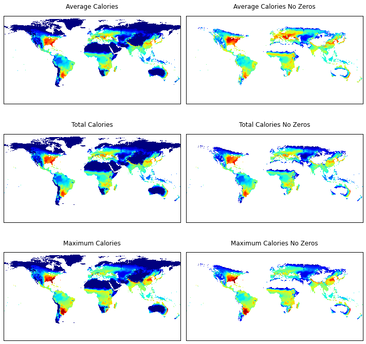

```python
f, ((ax1, ax2), (ax3, ax4), (ax5, ax6)) = plt.subplots(3,2,figsize=(10,10))
# Subplot 1
ax1.matshow(post1500mean.raster)
ax1.set_title('Average Calories')
ax1.set_xticks([],[])
ax1.set_yticks([],[])
# Subplot 2
ax2.matshow(post1500mean0.raster)
ax2.set_title('Average Calories No Zeros')
ax2.set_xticks([],[])
ax2.set_yticks([],[])
# Subplot 3
ax3.matshow(post1500tot.raster)
ax3.set_title('Total Calories')
ax3.set_xticks([],[])
ax3.set_yticks([],[])
# Subplot 4
ax4.matshow(post1500tot0.raster)
ax4.set_title('Total Calories No Zeros')
ax4.set_xticks([],[])
ax4.set_yticks([],[])
# Subplot 5
ax5.matshow(post1500max.raster)
ax5.set_title('Maximum Calories')
ax5.set_xticks([],[])
ax5.set_yticks([],[])
# Subplot 6
ax6.matshow(post1500max0.raster)
ax6.set_title('Maximum Calories No Zeros')
ax6.set_xticks([],[])
ax6.set_yticks([],[])
plt.tight_layout()
plt.show()
```

## Import Pre-1500CE Caloric Suitability Indices

```python
pre1500mean = gr.from_file('../data/pre1500AverageCalories.tif')
pre1500tot = gr.from_file('../data/pre1500TotalCalories.tif')
pre1500mean0 = gr.from_file('../data/pre1500AverageCaloriesNo0.tif')
pre1500tot0 = gr.from_file('../data/pre1500TotalCaloriesNo0.tif')
pre1500max = gr.from_file('../data/pre1500OptCalories.tif')
pre1500max0 = gr.from_file('../data/pre1500OptCaloriesNo0.tif')
```

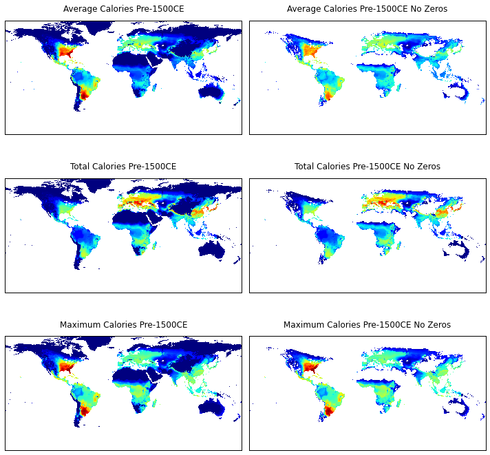

```python
f, ((ax1, ax2), (ax3, ax4), (ax5, ax6)) = plt.subplots(3,2,figsize=(10,10))
# Subplot 1
ax1.matshow(pre1500mean.raster)
ax1.set_title('Average Calories Pre-1500CE')
ax1.set_xticks([],[])
ax1.set_yticks([],[])
# Subplot 2
ax2.matshow(pre1500mean0.raster)
ax2.set_title('Average Calories Pre-1500CE No Zeros')
ax2.set_xticks([],[])
ax2.set_yticks([],[])
# Subplot 3
ax3.matshow(pre1500tot.raster)
ax3.set_title('Total Calories Pre-1500CE')
ax3.set_xticks([],[])
ax3.set_yticks([],[])
# Subplot 4
ax4.matshow(pre1500tot0.raster)
ax4.set_title('Total Calories Pre-1500CE No Zeros')
ax4.set_xticks([],[])
ax4.set_yticks([],[])
# Subplot 5
ax5.matshow(pre1500max.raster)
ax5.set_title('Maximum Calories Pre-1500CE')
ax5.set_xticks([],[])
ax5.set_yticks([],[])
# Subplot 6
ax6.matshow(pre1500max0.raster)
ax6.set_title('Maximum Calories Pre-1500CE No Zeros')
ax6.set_xticks([],[])
ax6.set_yticks([],[])
plt.tight_layout()
plt.show()
```

## Import Rammankutty et al. data

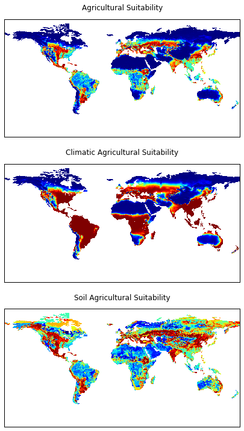

```python
rammankutty = gr.from_file('../data/suit.tif')
climrammankutty = gr.from_file('../data/climfac.tif')
soilrammankutty = gr.from_file('../data/soilfac.tif')

f, (ax1, ax2, ax3) = plt.subplots(3,1,figsize=(10,10))
ax1.matshow(rammankutty.raster)
ax1.set_title('Agricultural Suitability')
ax1.set_xticks([],[])
ax1.set_yticks([],[])
ax2.matshow(climrammankutty.raster)
ax2.set_title('Climatic Agricultural Suitability')
ax2.set_xticks([],[])
ax2.set_yticks([],[])
ax3.matshow(soilrammankutty.raster)
ax3.set_title('Soil Agricultural Suitability')
ax3.set_xticks([],[])
ax3.set_yticks([],[])
plt.tight_layout(h_pad=2.25)
plt.show()
```

As can be seen in the figures, most of the variation in *Agricultural Suitability* comes from the *Soil* component and not from the *Climatic* component. Thus, the use of the index in most economic research might be problematic, since for most research questions, especially in comparative development and long-run growth, the measure might be affected by human intervention.

## Differences between both data sets

### 1. Caloric Suitability Indices of Galor and Özak have finer resolutions

Let's look at the sizes of the rasters

```python
print rammankutty.shape
print post1500mean.shape
print pre1500mean.shape
```

```
(360, 720)
(2160, 4320)
(2084, 4320)
```

### 2. Caloric Suitability Indices are different and more essential than and Agricultural Suitability

Human existence requires consumption of sufficient calories. Thus, one can expect that mankind would evolve in regions that allow the effcient production of calories. While one can expect that agricultural and caloric suitability be (positively) correlated, they clearly are not the same concept, nor do they measure the same underlying process. In particular, as the following plots show, for any given probability of a cell being suitable for agriculture (as measured by Rammankutty et al.), the Caloric Suitability Indices varies over the full range of its possible values.

```python
rammankutty2=rammankutty.resize(post1500mean.shape)
```

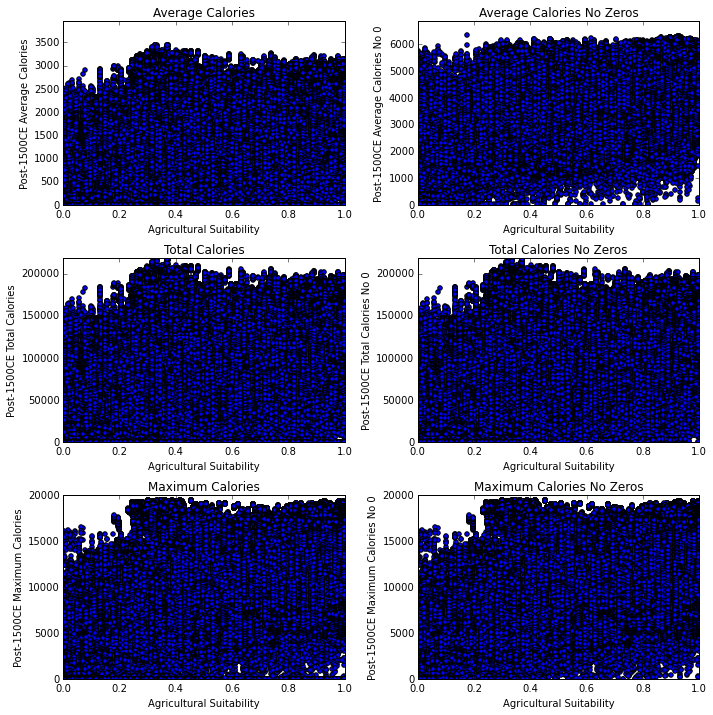

```python
f, axs = plt.subplots(3,2,figsize=(10,10))
plt.subplot(3, 2, 1)
plt.scatter(rammankutty2.raster.ravel(),post1500mean.raster.ravel());
plt.xlabel('Agricultural Suitability')
plt.ylabel('Post-1500CE Average Calories')
plt.title('Average Calories')
plt.xlim(0,1)
plt.ylim(0, post1500mean.max()+500)
plt.subplot(3, 2, 2)
plt.scatter(rammankutty2.raster.ravel(),post1500mean0.raster.ravel());
plt.xlabel('Agricultural Suitability')
plt.ylabel('Post-1500CE Average Calories No 0')
plt.title('Average Calories No Zeros')
plt.xlim(0,1)
plt.ylim(0, post1500mean0.max()+500)
plt.subplot(3, 2, 3)
plt.scatter(rammankutty2.raster.ravel(),post1500tot.raster.ravel());
plt.xlabel('Agricultural Suitability')
plt.ylabel('Post-1500CE Total Calories')
plt.title('Total Calories')
plt.xlim(0,1)
plt.ylim(0, post1500tot.max()+500)
plt.subplot(3, 2, 4)
plt.scatter(rammankutty2.raster.ravel(),post1500tot0.raster.ravel());
plt.xlabel('Agricultural Suitability')
plt.ylabel('Post-1500CE Total Calories No 0')
plt.title('Total Calories No Zeros')
plt.xlim(0,1)
plt.ylim(0, post1500tot0.max()+500)
plt.subplot(3, 2, 5)
plt.scatter(rammankutty2.raster.ravel(),post1500max.raster.ravel());
plt.xlabel('Agricultural Suitability')
plt.ylabel('Post-1500CE Maximum Calories')
plt.title('Maximum Calories')
plt.xlim(0,1)
plt.ylim(0, post1500max.max()+500)
plt.subplot(3, 2, 6)
plt.scatter(rammankutty2.raster.ravel(),post1500max0.raster.ravel());
plt.xlabel('Agricultural Suitability')
plt.ylabel('Post-1500CE Maximum Calories No 0')
plt.title('Maximum Calories No Zeros')
plt.xlim(0,1)
plt.ylim(0, post1500max0.max()+500)
plt.tight_layout(h_pad=1.25)
plt.show()
```

Similar results if instead one uses the Pre-1500CE Caloric Suitability Indices

```python
rammankutty2=rammankutty.resize(pre1500mean.shape)
```

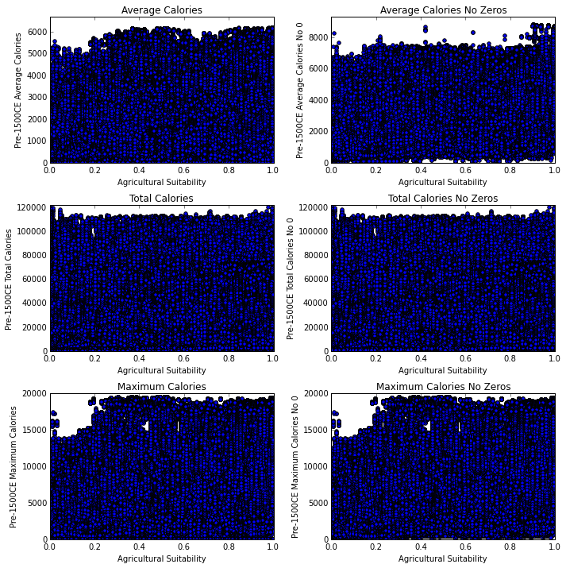

```python
f, axs = plt.subplots(3,2,figsize=(10,10))
plt.subplot(3, 2, 1)
plt.scatter(rammankutty2.raster.ravel(),pre1500mean.raster.ravel());
plt.xlabel('Agricultural Suitability')
plt.ylabel('Pre-1500CE Average Calories')
plt.title('Average Calories')
plt.xlim(0,1)
plt.ylim(0, pre1500mean.max()+500)
plt.subplot(3, 2, 2)
plt.scatter(rammankutty2.raster.ravel(),pre1500mean0.raster.ravel());
plt.xlabel('Agricultural Suitability')
plt.ylabel('Pre-1500CE Average Calories No 0')
plt.title('Average Calories No Zeros')
plt.xlim(0,1)
plt.ylim(0, pre1500mean0.max()+500)
plt.subplot(3, 2, 3)
plt.scatter(rammankutty2.raster.ravel(),pre1500tot.raster.ravel());
plt.xlabel('Agricultural Suitability')
plt.ylabel('Pre-1500CE Total Calories')
plt.title('Total Calories')
plt.xlim(0,1)
plt.ylim(0, pre1500tot.max()+500)
plt.subplot(3, 2, 4)
plt.scatter(rammankutty2.raster.ravel(),pre1500tot0.raster.ravel());
plt.xlabel('Agricultural Suitability')
plt.ylabel('Pre-1500CE Total Calories No 0')
plt.title('Total Calories No Zeros')
plt.xlim(0,1)
plt.ylim(0, pre1500tot0.max()+500)
plt.subplot(3, 2, 5)
plt.scatter(rammankutty2.raster.ravel(),pre1500max.raster.ravel());
plt.xlabel('Agricultural Suitability')
plt.ylabel('Pre-1500CE Maximum Calories')
plt.title('Maximum Calories')
plt.xlim(0,1)
plt.ylim(0, pre1500max.max()+500)
plt.subplot(3, 2, 6)
plt.scatter(rammankutty2.raster.ravel(),pre1500max0.raster.ravel());
plt.xlabel('Agricultural Suitability')
plt.ylabel('Pre-1500CE Maximum Calories No 0')
plt.title('Maximum Calories No Zeros')
plt.xlim(0,1)
plt.ylim(0, pre1500max0.max()+500)
plt.tight_layout(h_pad=1.25)
plt.show()
```

Similar results if instead of *Agricultural Suitability* one uses the *Climatic* component

```python
rammankutty2=climrammankutty.resize(pre1500mean.shape)
```

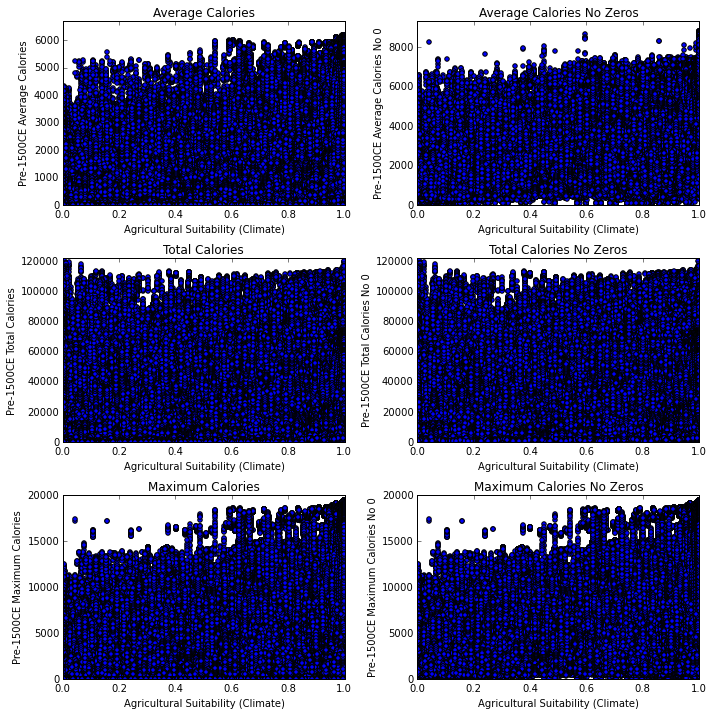

```python
f, axs = plt.subplots(3,2,figsize=(10,10))
plt.subplot(3, 2, 1)
plt.scatter(rammankutty2.raster.ravel(),pre1500mean.raster.ravel());
plt.xlabel('Agricultural Suitability (Climate)')
plt.ylabel('Pre-1500CE Average Calories')
plt.title('Average Calories')
plt.xlim(0,1)
plt.ylim(0, pre1500mean.max()+500)
plt.subplot(3, 2, 2)
plt.scatter(rammankutty2.raster.ravel(),pre1500mean0.raster.ravel());
plt.xlabel('Agricultural Suitability (Climate)')
plt.ylabel('Pre-1500CE Average Calories No 0')
plt.title('Average Calories No Zeros')
plt.xlim(0,1)
plt.ylim(0, pre1500mean0.max()+500)
plt.subplot(3, 2, 3)
plt.scatter(rammankutty2.raster.ravel(),pre1500tot.raster.ravel());
plt.xlabel('Agricultural Suitability (Climate)')
plt.ylabel('Pre-1500CE Total Calories')
plt.title('Total Calories')
plt.xlim(0,1)
plt.ylim(0, pre1500tot.max()+500)
plt.subplot(3, 2, 4)
plt.scatter(rammankutty2.raster.ravel(),pre1500tot0.raster.ravel());
plt.xlabel('Agricultural Suitability (Climate)')
plt.ylabel('Pre-1500CE Total Calories No 0')
plt.title('Total Calories No Zeros')
plt.xlim(0,1)
plt.ylim(0, pre1500tot0.max()+500)
plt.subplot(3, 2, 5)
plt.scatter(rammankutty2.raster.ravel(),pre1500max.raster.ravel());
plt.xlabel('Agricultural Suitability (Climate)')
plt.ylabel('Pre-1500CE Maximum Calories')
plt.title('Maximum Calories')
plt.xlim(0,1)
plt.ylim(0, pre1500max.max()+500)
plt.subplot(3, 2, 6)
plt.scatter(rammankutty2.raster.ravel(),pre1500max0.raster.ravel());
plt.xlabel('Agricultural Suitability (Climate)')
plt.ylabel('Pre-1500CE Maximum Calories No 0')
plt.title('Maximum Calories No Zeros')
plt.xlim(0,1)
plt.ylim(0, pre1500max0.max()+500)
plt.tight_layout(h_pad=1.25)
plt.show()
```